# Exploratory Data Analysis — Films

Jakub Groblicki

2026-03-19

# Introduction

This report presents an Exploratory Data Analysis (EDA) of a dataset of feature films. The analysis examines financial outcomes (budget, box office revenue, and earnings), IMDb audience ratings, and selected descriptive attributes of productions including genre, release year, director, and cast.

The analysis is structured around three research questions:

1. **What factors are associated with a film posting a negative financial result?**
2. **What influences a film’s IMDb rating?**
3. **Do industry-recognised films differ systematically from the rest?**

All findings are exploratory — they describe patterns, distributions and associations observed in the data, and do not imply causal relationships.

# Dataset

## Description

The dataset contains information on feature films drawn from several decades of theatrical releases. Each row corresponds to one film and includes financial figures, IMDb scores, and descriptive attributes.

| Variable | Type | Description |
| --- | --- | --- |
| `Movie` | Text | Film title |
| `Director` | Text | Director’s name |
| `Running time` | Numeric | Duration (minutes) |
| `Actor 1` | Text | Lead actor |
| `Actor 2` | Text | Supporting actor |
| `Actor 3` | Text | Third-billed actor |
| `Genre` | Categorical | Genre (e.g. Action, Comedy, Drama) |
| `Budget` | Numeric | Production budget (USD) |
| `Box Office` | Numeric | Total theatrical revenue (USD) |
| `Actors Box Office %` | Numeric | % of the cast’s prior films where box office ≥ 2× budget |
| `Director Box Office %` | Numeric | % of the director’s prior films where box office ≥ 2× budget |
| `Earnings` | Numeric | Profit = Box Office − Budget (USD) |
| `Oscar and Golden Globes nominations` | Numeric | Total Oscar and Golden Globe nominations received |
| `Oscar and Golden Globes awards` | Numeric | Total Oscars and Golden Globes won |
| `Release year` | Numeric | Year of theatrical release |
| `IMDb score` | Numeric | Mean IMDb audience rating (scale 1–10) |

## Loading the Data

```r
movies <- readr::read_csv(
  "movies_data.csv",
  locale = readr::locale(encoding = "windows-1252")
)
```

A preview of the first and last rows confirms the general structure and format of the data:

```r
head(movies, 5)
```

| Movie | Director | Running time | Actor 1 | Actor 2 | Actor 3 | Genre | Budget | Box Office | Actors Box Office % | Director Box Office % | Earnings | Oscar and Golden Globes nominations | Oscar and Golden Globes awards | Release year | IMDb score |
| --- | --- | --- | --- | --- | --- | --- | --- | --- | --- | --- | --- | --- | --- | --- | --- |
| 13 Hours | Michael Bay | 144 | Toby Stephens | James Badge Dale | David Costabile | Action | 5.0e+07 | 6.94e+07 | 50.00 | 69.23 | 1.94e+07 | 0 | 0 | 2016 | 7.4 |
| 16 Blocks | Richard Donner | 102 | Bruce Willis | David Zayas | Sasha Roiz | Action | 5.2e+07 | 6.50e+07 | 33.33 | 50.00 | 1.30e+07 | 0 | 0 | 2006 | 6.6 |
| 17 Again | Burr Steers | 102 | Matthew Perry | Hunter Parrish | Thomas Lennon | Comedy | 2.0e+07 | 1.39e+08 | 44.44 | 25.00 | 1.19e+08 | 0 | 0 | 2009 | 6.4 |
| 1982 | Tommy Oliver | 90 | Bokeem Woodbine | Ruby Dee | Quinton Aaron | Drama | 1.0e+06 | 2.00e+06 | 50.00 | 100.00 | 1.00e+06 | 0 | 0 | 2013 | 7.1 |
| 2 Fast 2 Furious | John Singleton | 107 | Paul Walker | Cole Hauser | Mo Gallini | Action | 7.6e+07 | 2.36e+08 | 75.00 | 42.85 | 1.60e+08 | 0 | 0 | 2003 | 5.9 |

```r
tail(movies, 5)
```

| Movie | Director | Running time | Actor 1 | Actor 2 | Actor 3 | Genre | Budget | Box Office | Actors Box Office % | Director Box Office % | Earnings | Oscar and Golden Globes nominations | Oscar and Golden Globes awards | Release year | IMDb score |
| --- | --- | --- | --- | --- | --- | --- | --- | --- | --- | --- | --- | --- | --- | --- | --- |
| Z Storm | David Lam | 92 | Michael Wong | Louis Koo | Stephen Au | Action | 7000000 | 1.70e+07 | 100.00 | 100.00 | 10000000 | 0 | 0 | 2014 | 5.3 |
| Zack and Miri Make a Porno | Kevin Smith | 101 | Gerry Bednob | Jeff Anderson | Jennifer Schwalbach Smith | Comedy | 24000000 | 4.20e+07 | 66.67 | 41.66 | 18000000 | 0 | 0 | 2008 | 6.6 |
| Zero Effect | Jake Kasdan | 116 | Kim Dickens | Ryan O'Neal | Angela Featherstone | Comedy | 5000000 | 2.00e+06 | 33.33 | 50.00 | -3000000 | 0 | 0 | 1998 | 7.0 |
| Zombieland | Ruben Fleischer | 88 | Emma Stone | Bill Murray | Derek Graf | Adventure | 23600000 | 1.02e+08 | 66.67 | 33.33 | 78400000 | 0 | 0 | 2009 | 7.7 |
| Zulu | Jér?me Salle | 110 | Orlando Bloom | Tanya van Graan | Conrad Kemp | Crime | 16000000 | 5.00e+06 | 0.00 | 0.00 | -11000000 | 0 | 0 | 2013 | 6.7 |

```r
str(movies)
```

```
## spc_tbl_ [3,974 × 16] (S3: spec_tbl_df/tbl_df/tbl/data.frame)
##  $ Movie                              : chr [1:3974] "13 Hours" "16 Blocks" "17 Again" "1982" ...
##  $ Director                           : chr [1:3974] "Michael Bay" "Richard Donner" "Burr Steers" "Tommy Oliver" ...
##  $ Running time                       : num [1:3974] 144 102 102 90 107 109 158 123 112 111 ...
##  $ Actor 1                            : chr [1:3974] "Toby Stephens" "Bruce Willis" "Matthew Perry" "Bokeem Woodbine" ...
##  $ Actor 2                            : chr [1:3974] "James Badge Dale" "David Zayas" "Hunter Parrish" "Ruby Dee" ...
##  $ Actor 3                            : chr [1:3974] "David Costabile" "Sasha Roiz" "Thomas Lennon" "Quinton Aaron" ...
##  $ Genre                              : chr [1:3974] "Action" "Action" "Comedy" "Drama" ...
##  $ Budget                             : num [1:3974] 5.0e+07 5.2e+07 2.0e+07 1.0e+06 7.6e+07 6.1e+07 2.0e+08 3.5e+07 5.0e+07 3.0e+07 ...
##  $ Box Office                         : num [1:3974] 6.94e+07 6.50e+07 1.39e+08 2.00e+06 2.36e+08 1.32e+08 8.00e+08 8.10e+07 3.31e+08 1.60e+08 ...
##  $ Actors Box Office %                : num [1:3974] 50 33.3 44.4 50 75 ...
##  $ Director Box Office %              : num [1:3974] 69.2 50 25 100 42.9 ...
##  $ Earnings                           : num [1:3974] 1.94e+07 1.30e+07 1.19e+08 1.00e+06 1.60e+08 7.10e+07 6.00e+08 4.60e+07 2.81e+08 1.30e+08 ...
##  $ Oscar and Golden Globes nominations: num [1:3974] 0 0 0 0 0 0 0 0 0 0 ...
##  $ Oscar and Golden Globes awards     : num [1:3974] 0 0 0 0 0 0 0 0 0 0 ...
##  $ Release year                       : num [1:3974] 2016 2006 2009 2013 2003 ...
##  $ IMDb score                         : num [1:3974] 7.4 6.6 6.4 7.1 5.9 6.7 5.8 6.8 7.1 6.1 ...
##  - attr(*, "spec")=
##   .. cols(
##   ..   Movie = col_character(),
##   ..   Director = col_character(),
##   ..   `Running time` = col_double(),
##   ..   `Actor 1` = col_character(),
##   ..   `Actor 2` = col_character(),
##   ..   `Actor 3` = col_character(),
##   ..   Genre = col_character(),
##   ..   Budget = col_double(),
##   ..   `Box Office` = col_double(),
##   ..   `Actors Box Office %` = col_double(),
##   ..   `Director Box Office %` = col_double(),
##   ..   Earnings = col_double(),
##   ..   `Oscar and Golden Globes nominations` = col_double(),
##   ..   `Oscar and Golden Globes awards` = col_double(),
##   ..   `Release year` = col_double(),
##   ..   `IMDb score` = col_double()
##   .. )
##  - attr(*, "problems")=<externalptr>
```

## Data Cleaning

### Missing values

```r
anyNA(movies)
```

```
## [1] TRUE
```

```r
colSums(is.na(movies))
```

```
##                               Movie                            Director
##                                   0                                   0
##                        Running time                             Actor 1
##                                   0                                   0
##                             Actor 2                             Actor 3
##                                   0                                   2
##                               Genre                              Budget
##                                   0                                   0
##                          Box Office                 Actors Box Office %
##                                   0                                   0
##               Director Box Office %                            Earnings
##                                   0                                   0
## Oscar and Golden Globes nominations      Oscar and Golden Globes awards
##                                   0                                   3
##                        Release year                          IMDb score
##                                   0                                   0
```

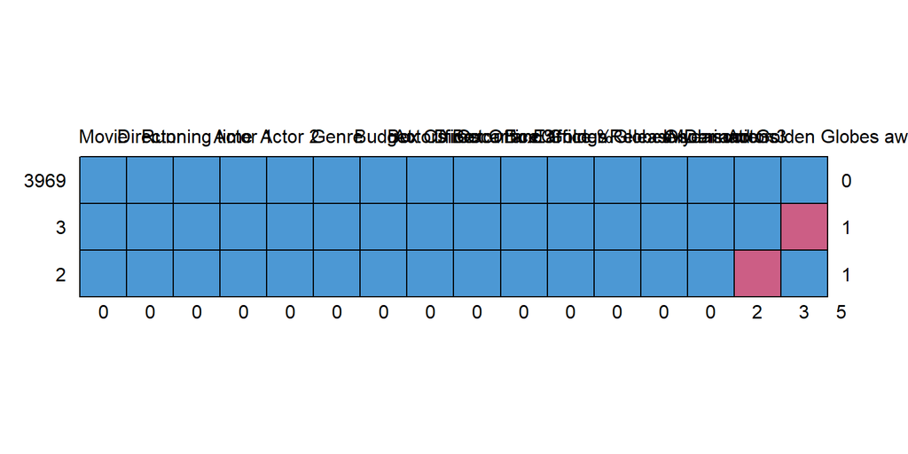

```
##      Movie Director Running time Actor 1 Actor 2 Genre Budget Box Office
## 3969     1        1            1       1       1     1      1          1
## 3        1        1            1       1       1     1      1          1
## 2        1        1            1       1       1     1      1          1
##          0        0            0       0       0     0      0          0
##      Actors Box Office % Director Box Office % Earnings
## 3969                   1                     1        1
## 3                      1                     1        1
## 2                      1                     1        1
##                        0                     0        0
##      Oscar and Golden Globes nominations Release year IMDb score Actor 3
## 3969                                   1            1          1       1
## 3                                      1            1          1       1
## 2                                      1            1          1       0
##                                        0            0          0       2
##      Oscar and Golden Globes awards
## 3969                              1 0
## 3                                 0 1
## 2                                 1 1
##                                   3 5
```

```r
md.pattern(movies)
```

Missing values are confined to two columns. `Actor 3` has 2 missing entries — a third-billed actor is simply absent for many productions, so these are replaced with `"Unknown"`. `Oscar and Golden Globes awards` has 3 missing entries. Before imputing, we verify that all affected films also have zero nominations — which would confirm the missing value means *no award won* rather than a data collection failure:

```r
na_awards_idx <- is.na(movies$`Oscar and Golden Globes awards`)
cat("Nomination counts for films with missing award values:\n")
```

```
## Nomination counts for films with missing award values:
```

```r
table(movies$`Oscar and Golden Globes nominations`[na_awards_idx])
```

```
##
## 2 3 4
## 1 1 1
```

```r
movies$`Oscar and Golden Globes awards`[na_awards_idx] <- 0
movies$`Actor 3`[is.na(movies$`Actor 3`)] <- "Unknown"
```

### Duplicate rows

```r
cat("Duplicate rows found:", sum(duplicated(movies)), "\n")
```

```
## Duplicate rows found: 24
```

```r
movies <- movies[!duplicated(movies), ]
cat("Rows retained after deduplication:", nrow(movies), "\n")
```

```
## Rows retained after deduplication: 3950
```

## Data Preparation

### Type conversion

`Genre` is converted to a factor to ensure correct grouping behaviour and ordered axis labels in plots:

```r
movies$Genre <- as.factor(movies$Genre)
cat("Genres present:", paste(levels(movies$Genre), collapse = ", "), "\n")
```

```
## Genres present: Action, Adventure, Animation, Biography, Comedy, Crime, Documentary, Drama, Horror, Mystery, Romance, Sci-Fi, Thriller, Western
```

The dataset contains 14 distinct genres.

### Verifying `Earnings`

We confirm that `Earnings` equals Box Office − Budget for every row, and that it does not incorporate other revenue streams such as rights sales or merchandise:

```r
all_zero <- all((movies$Earnings - (movies$`Box Office` - movies$Budget)) == 0)
cat("Earnings equals Box Office minus Budget for all rows:", all_zero, "\n")
```

```
## Earnings equals Box Office minus Budget for all rows: TRUE
```

The check confirms a perfect identity. `Earnings` reflects theatrical revenues only — a point worth bearing in mind throughout the financial analysis, since real profitability would also depend on home release, streaming rights, and ancillary markets.

### Adding the ROI variable

Raw earnings are scale-dependent: a $300M profit means something very different on a $30M budget than on a $250M budget. We add a **Return on Investment** ratio (`roi = Box Office / Budget`) to capture relative financial performance alongside absolute earnings:

```r
movies <- movies %>% mutate(roi = `Box Office` / Budget)
summary(movies$roi)
```

```
##      Min.   1st Qu.    Median      Mean   3rd Qu.      Max.
## 1.100e-03 9.909e-01 2.105e+00 9.593e+00 4.167e+00 1.287e+04
```

A film with `roi > 1` recovered its production costs from theatrical revenues alone. An `roi > 2` is a common industry benchmark for a commercially successful release.

### Correcting `Actors Box Office %`

`Actors Box Office %` is a percentage (range 0–100) representing the proportion of an actor’s prior films where box office reached at least 2× the production budget. Any value above 100 is logically impossible and indicates a data entry error:

```r
cat("Records with Actors Box Office % > 100:",
    sum(movies$`Actors Box Office %` > 100, na.rm = TRUE), "\n")
```

```
## Records with Actors Box Office % > 100: 2
```

```r
movies$`Actors Box Office %`[movies$`Actors Box Office %` > 100] <- NA

cat("Records with Actors Box Office % > 100 after correction:",
    sum(movies$`Actors Box Office %` > 100, na.rm = TRUE), "\n")
```

```
## Records with Actors Box Office % > 100 after correction: 0
```

Both erroneous records are replaced with `NA`.

### Pre-computing director performance groups

To avoid repeating the same `cut()` call across multiple sections, the director performance quartile grouping is computed once here and reused throughout:

```r
movies <- movies %>%
  mutate(
    director_group = cut(
      `Director Box Office %`,
      breaks = quantile(`Director Box Office %`,
                        probs = c(0, .25, .5, .75, 1), na.rm = TRUE),
      labels = c("Low (Q1)", "Mid-low (Q2)", "Mid-high (Q3)", "High (Q4)"),
      include.lowest = TRUE
    )
  )
```

## Descriptive Statistics

```r
num_cols <- c("Running time", "Budget", "Box Office",
              "Actors Box Office %", "Director Box Office %",
              "Earnings", "roi",
              "Oscar and Golden Globes nominations",
              "Oscar and Golden Globes awards",
              "Release year", "IMDb score")

summary(movies[, num_cols])
```

```
##   Running time     Budget            Box Office        Actors Box Office %
##  Min.   : 20   Min.   :     1100   Min.   :5.000e+04   Min.   :  0.00
##  1st Qu.: 95   1st Qu.:  9000000   1st Qu.:1.200e+07   1st Qu.: 33.33
##  Median :106   Median : 22000000   Median :4.300e+07   Median : 57.14
##  Mean   :110   Mean   : 36874481   Mean   :1.086e+08   Mean   : 56.20
##  3rd Qu.:120   3rd Qu.: 50000000   3rd Qu.:1.250e+08   3rd Qu.: 83.33
##  Max.   :330   Max.   :390000000   Max.   :2.923e+09   Max.   :100.00
##                                                        NA's   :2
##  Director Box Office %    Earnings               roi
##  Min.   :  0.00        Min.   :-323100000   Min.   :1.100e-03
##  1st Qu.: 25.00        1st Qu.:    -62125   1st Qu.:9.909e-01
##  Median : 50.00        Median :  18000000   Median :2.105e+00
##  Mean   : 52.72        Mean   :  71707256   Mean   :9.593e+00
##  3rd Qu.: 80.00        3rd Qu.:  80000000   3rd Qu.:4.167e+00
##  Max.   :100.00        Max.   :2686000000   Max.   :1.287e+04
##
##  Oscar and Golden Globes nominations Oscar and Golden Globes awards
##  Min.   : 0.000                      Min.   : 0.000
##  1st Qu.: 0.000                      1st Qu.: 0.000
##  Median : 0.000                      Median : 0.000
##  Mean   : 1.111                      Mean   : 0.323
##  3rd Qu.: 1.000                      3rd Qu.: 0.000
##  Max.   :22.000                      Max.   :13.000
##
##   Release year    IMDb score
##  Min.   :1929   Min.   :1.600
##  1st Qu.:1998   1st Qu.:5.900
##  Median :2005   Median :6.600
##  Mean   :2002   Mean   :6.468
##  3rd Qu.:2010   3rd Qu.:7.200
##  Max.   :2016   Max.   :9.300
##
```

The `psych` package extends the summary with shape measures — skewness and kurtosis:

```r
describe(movies[, num_cols]) %>%
  select(n, mean, sd, median, min, max, skew, kurtosis) %>%
  round(2)
```

|  | n | mean | sd | median | min | max | skew | kurtosis |
| --- | --- | --- | --- | --- | --- | --- | --- | --- |
| Running time | 3950 | 110.00 | 22.56 | 1.060e+02 | 2.000e+01 | 3.300000e+02 | 2.19 | 10.95 |
| Budget | 3950 | 36874481.41 | 42712600.19 | 2.200e+07 | 1.100e+03 | 3.900000e+08 | 2.26 | 6.37 |
| Box Office | 3950 | 108581736.96 | 180199366.53 | 4.300e+07 | 5.000e+04 | 2.923000e+09 | 4.19 | 30.69 |
| Actors Box Office % | 3948 | 56.20 | 30.02 | 5.714e+01 | 0.000e+00 | 1.000000e+02 | -0.22 | -0.92 |
| Director Box Office % | 3950 | 52.72 | 35.37 | 5.000e+01 | 0.000e+00 | 1.000000e+02 | -0.18 | -1.18 |
| Earnings | 3950 | 71707255.55 | 152967402.64 | 1.800e+07 | -3.231e+08 | 2.686000e+09 | 4.72 | 40.49 |
| roi | 3950 | 9.59 | 215.80 | 2.110e+00 | 0.000e+00 | 1.286667e+04 | 55.32 | 3220.71 |
| Oscar and Golden Globes nominations | 3950 | 1.11 | 2.73 | 0.000e+00 | 0.000e+00 | 2.200000e+01 | 3.44 | 13.29 |
| Oscar and Golden Globes awards | 3950 | 0.32 | 1.21 | 0.000e+00 | 0.000e+00 | 1.300000e+01 | 5.46 | 36.16 |
| Release year | 3950 | 2002.03 | 12.12 | 2.005e+03 | 1.929e+03 | 2.016000e+03 | -2.11 | 6.38 |

[output cut: 1 more lines]

**Kurtosis convention.** `psych::describe()` reports *excess kurtosis* (standard Pearson kurtosis minus 3). A normal distribution therefore has excess kurtosis = 0. Positive values denote heavier tails than normal (leptokurtic); negative values denote lighter tails (platykurtic).

The most striking feature of the descriptive table is the strong right-skewness of all financial variables. `Budget` and `Box Office` exhibit very long right tails — a pattern typical of entertainment industry data, where revenue is highly concentrated around a few major blockbusters. `Earnings` is similarly asymmetric, centred around small positive values with a pronounced right tail from major hits and a visible left tail from loss-making productions. This distributional shape has a direct methodological implication: **robust location measures (median, IQR) and non-parametric inferential tests are the appropriate tools for all financial variables** throughout this analysis.

### Distributions of financial variables

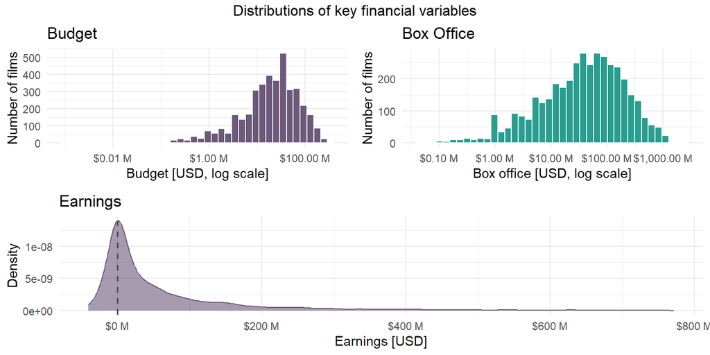

```r
p1 <- ggplot(movies, aes(x = Budget)) +
  geom_histogram(fill = col_nom, colour = "white", bins = 40) +
  scale_x_log10(labels = label_dollar(scale = 1e-6, suffix = " M")) +
  labs(title = "Budget", x = "Budget [USD, log scale]",
       y = "Number of films") +
  theme_minimal(base_size = 11)

p2 <- ggplot(movies, aes(x = `Box Office`)) +
  geom_histogram(fill = col_profit, colour = "white", bins = 40) +
  scale_x_log10(labels = label_dollar(scale = 1e-6, suffix = " M")) +
  labs(title = "Box Office", x = "Box office [USD, log scale]",
       y = "Number of films") +
  theme_minimal(base_size = 11)

p3 <- ggplot(movies, aes(x = Earnings)) +
  geom_density(fill = col_nom, alpha = 0.6, colour = col_nom) +
  geom_vline(xintercept = 0, linetype = "dashed", colour = "grey30", linewidth = 0.7) +
  scale_x_continuous(
    labels = label_dollar(scale = 1e-6, suffix = " M"),
    limits = c(
      quantile(movies$Earnings, 0.01),
      quantile(movies$Earnings, 0.99)
    )
  ) +
  labs(
    title = "Earnings",
    x     = "Earnings [USD]",
    y     = "Density"
  ) +
  theme_minimal(base_size = 11)

gridExtra::grid.arrange(
  p1, p2,
  p3,
  layout_matrix = rbind(c(1, 2),
                        c(3, 3)),
  top = "Distributions of key financial variables"
)
```

Both Budget and Box Office follow approximately log-normal distributions: roughly symmetric on the log scale, but strongly right-skewed on the original scale. The Earnings density plot confirms that the majority of films post a positive result, though the left tail of loss-making productions is clearly visible.

## Correlation Matrix

Before turning to the individual research questions, it is useful to survey the pairwise associations between all major variables simultaneously. We use **Spearman rank correlation**, which is robust to outliers and makes no assumption of linearity. `Earnings` is deliberately excluded from the matrix — since it is defined as Box Office − Budget, its Spearman correlation with those two variables is structurally inflated and does not carry independent information.

[figure not shown]

```r
cor_mat <- cor(
  movies[, c("IMDb score", "Budget", "Box Office",
             "Oscar and Golden Globes nominations",
             "Oscar and Golden Globes awards",
             "Release year",
             "Actors Box Office %",
             "Director Box Office %")],
  method = "spearman",
  use    = "pairwise.complete.obs"
)

corrplot(
  cor_mat,
  method      = "square",
  type        = "upper",
  tl.cex      = 0.85,
  tl.col      = "black",
  addCoef.col = "black",
  number.cex  = 0.70,
  col         = colorRampPalette(c(col_loss, "white", col_profit))(200),
  mar         = c(0, 0, 1, 0),
  title       = "Spearman rank correlations"
)
```

**A note on statistical significance at large sample sizes.** With n ≈ 3,900 observations, even correlations as small as |ρ| ≈ 0.03 will produce statistically significant p-values. Throughout this analysis, **the magnitude of ρ matters far more than its p-value.** We interpret effect sizes using Cohen’s benchmarks: |ρ| < 0.10 = negligible, 0.10–0.30 = small, 0.30–0.50 = medium, > 0.50 = large.

# Why Do Some Films Post a Negative Profit?

We begin by establishing the scale of the phenomenon:

```r
n_loss   <- sum(movies$Earnings < 0)
pct_loss <- round(mean(movies$Earnings < 0) * 100, 1)
cat("Films posting a loss:", n_loss,
    sprintf("(%.1f%% of the dataset)\n", pct_loss))
```

```
## Films posting a loss: 991 (25.1% of the dataset)
```

Approximately **25.1%** of films in the dataset recorded a negative theatrical result. This figure should be interpreted with care: as noted above, `Earnings` captures box office revenues only. Films that appear loss-making here may have recovered their budgets through home video, streaming rights, television licensing, or merchandising.

### Top 10 films by profit and loss

Before any aggregated analysis, it is instructive to inspect the films at both extremes of the earnings distribution:

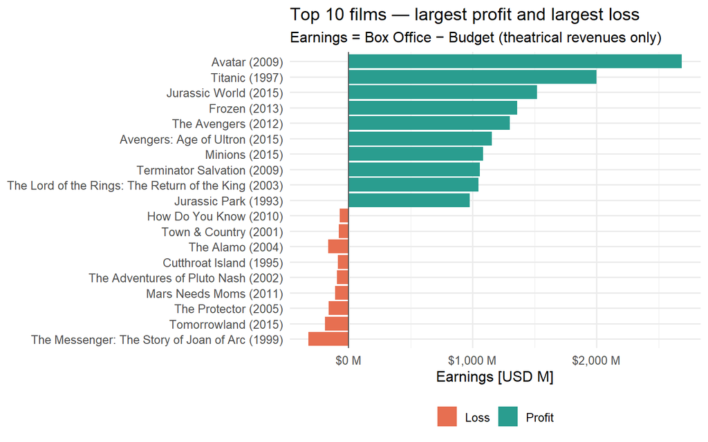

```r
top_profit <- movies %>%
  slice_max(Earnings, n = 10) %>%
  mutate(label = paste0(Movie, " (", `Release year`, ")"), result = "Profit")

top_loss <- movies %>%
  slice_min(Earnings, n = 10) %>%
  mutate(label = paste0(Movie, " (", `Release year`, ")"), result = "Loss")

bind_rows(top_profit, top_loss) %>%
  ggplot(aes(x = reorder(label, Earnings), y = Earnings / 1e6, fill = result)) +
  geom_col() +
  geom_hline(yintercept = 0, colour = "grey30", linewidth = 0.5) +
  coord_flip() +
  scale_fill_manual(values = c("Profit" = col_profit, "Loss" = col_loss)) +
  scale_y_continuous(labels = label_dollar(suffix = " M")) +
  labs(
    title    = "Top 10 films — largest profit and largest loss",
    subtitle = "Earnings = Box Office − Budget (theatrical revenues only)",
    x = NULL, y = "Earnings [USD M]", fill = NULL
  ) +
  theme_minimal(base_size = 12) +
  theme(legend.position = "bottom")
```

The asymmetry is striking: the largest profits comfortably exceed $700M, while the largest losses are roughly an order of magnitude smaller. This reflects the general structure of the industry — catastrophic flops are bounded by the size of their budgets, whereas a blockbuster can generate revenues many times its production cost.

## Does Genre Influence Financial Loss?

Comparing raw film counts by genre is a necessary first step, but inherently misleading — Action, Comedy and Drama simply produce more films in absolute terms, which mechanically generates more absolute losses:

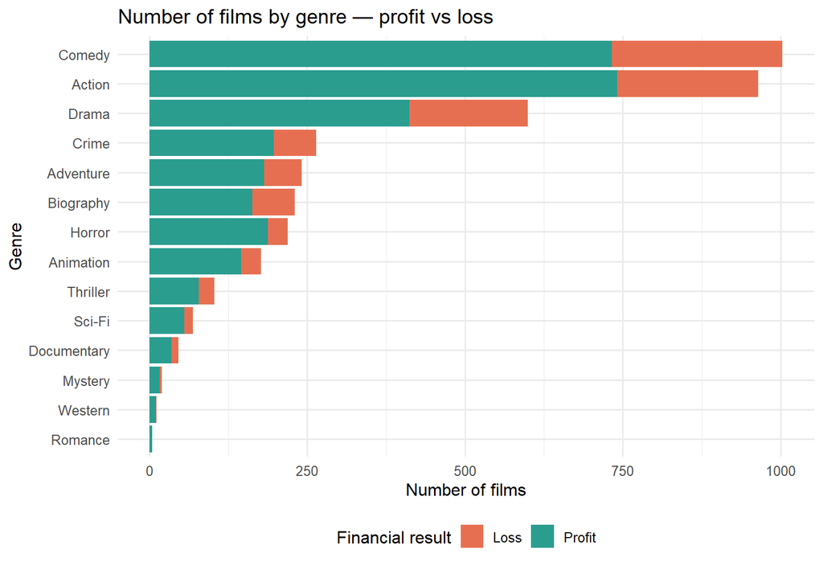

```r
movies %>%
  mutate(result = ifelse(Earnings >= 0, "Profit", "Loss")) %>%
  count(Genre, result) %>%
  ggplot(aes(x = reorder(Genre, n), y = n, fill = result)) +
  geom_col(position = "stack") +
  coord_flip() +
  scale_fill_manual(values = c("Profit" = col_profit, "Loss" = col_loss)) +
  labs(title = "Number of films by genre — profit vs loss",
       x = "Genre", y = "Number of films", fill = "Financial result") +
  theme_minimal(base_size = 12) +
  theme(legend.position = "bottom")
```

The meaningful comparison is the **proportion** of loss-making films within each genre, which controls for genre size:

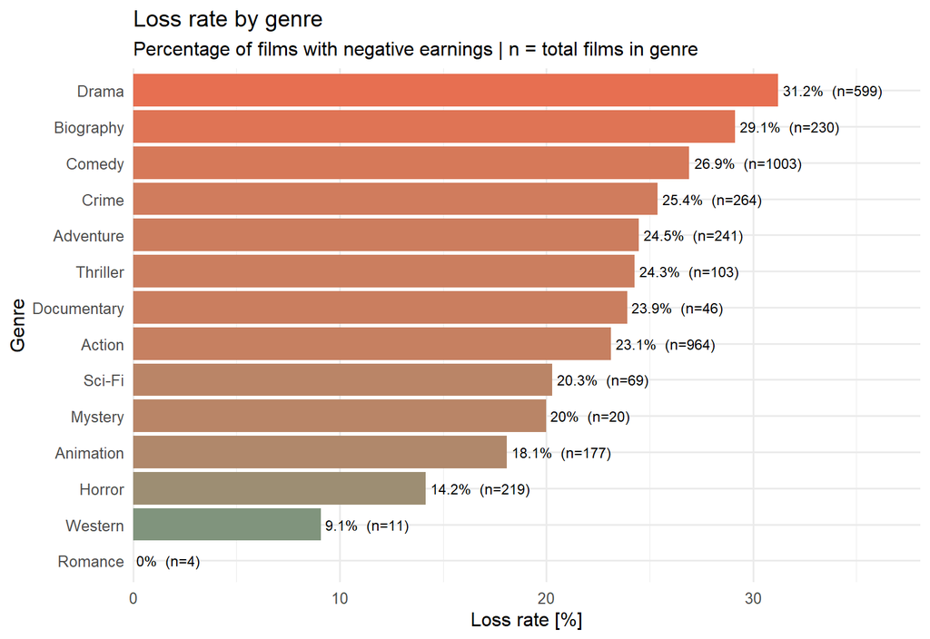

```r
genre_summary <- movies %>%
  group_by(Genre) %>%
  summarise(pct_loss = mean(Earnings < 0) * 100, n_films = n(), .groups = "drop")

ggplot(genre_summary,
       aes(x = reorder(Genre, pct_loss), y = pct_loss, fill = pct_loss)) +
  geom_col(show.legend = FALSE) +
  geom_text(aes(label = paste0(round(pct_loss, 1), "%  (n=", n_films, ")")),
            hjust = -0.05, size = 3.2) +
  coord_flip(clip = "off") +
  scale_fill_gradient(low = col_profit, high = col_loss) +
  scale_y_continuous(expand = expansion(mult = c(0, 0.22))) +
  labs(
    title    = "Loss rate by genre",
    subtitle = "Percentage of films with negative earnings | n = total films in genre",
    x = "Genre", y = "Loss rate [%]"
  ) +
  theme_minimal(base_size = 12)
```

Drama and Biography show the highest loss rates among well-represented genres, likely reflecting a combination of lower commercial appeal and niche audience bases alongside sometimes substantial production costs. The Romance genre registers a 0% loss rate, but with only 4 films this is a sampling artefact rather than a meaningful finding.

### Kruskal-Wallis test and Dunn post-hoc comparisons

To formally test whether earnings distributions differ significantly across genres, we apply the **Kruskal-Wallis test** — the non-parametric analogue of one-way ANOVA, which ranks all observations and tests whether the rank distributions are the same across groups. If the global test is significant, **Dunn’s post-hoc test** with Benjamini-Hochberg (BH) false discovery rate correction identifies which specific genre pairs drive the result.

> **H₀:** The earnings distribution is identical across all genres.

> **H₁:** At least one genre has a different earnings distribution.

```r
kw <- kruskal.test(Earnings ~ Genre, data = movies)
kw
```

```
##
##  Kruskal-Wallis rank sum test
##
## data:  Earnings by Genre
## Kruskal-Wallis chi-squared = 199.58, df = 13, p-value < 2.2e-16
```

```r
dunn_result <- dunn.test(
  movies$Earnings,
  movies$Genre,
  method = "bh",
  altp   = TRUE,
  list   = FALSE
)
```

## Does Release Year Influence Financial Loss?

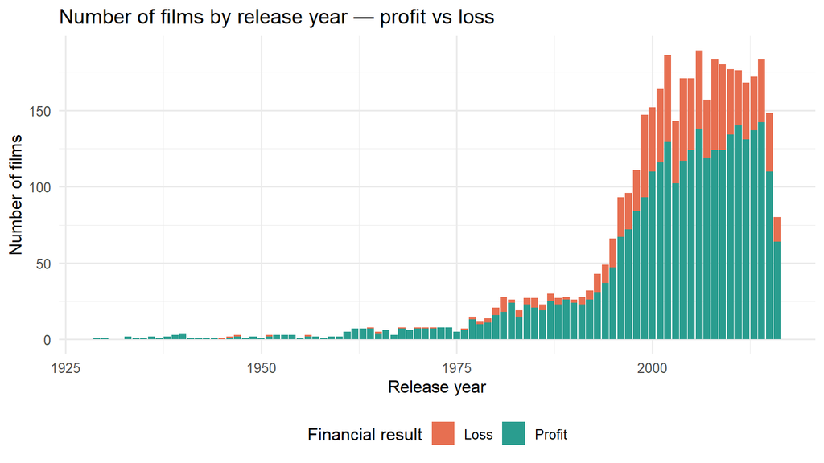

```r
movies %>%
  mutate(result = ifelse(Earnings >= 0, "Profit", "Loss")) %>%
  count(`Release year`, result) %>%
  ggplot(aes(x = `Release year`, y = n, fill = result)) +
  geom_col(position = "stack") +
  scale_fill_manual(values = c("Profit" = col_profit, "Loss" = col_loss)) +
  labs(title = "Number of films by release year — profit vs loss",
       x = "Release year", y = "Number of films", fill = "Financial result") +
  theme_minimal(base_size = 12) +
  theme(legend.position = "bottom")
```

Both profitable and loss-making films have grown in absolute number since the late 1990s, primarily reflecting a rapid expansion of film production volume rather than a deterioration of industry economics. As with genres, raw counts conceal the more informative picture — proportions:

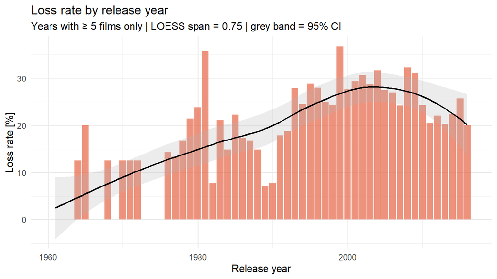

```r
movies %>%
  group_by(`Release year`) %>%
  summarise(pct_loss = mean(Earnings < 0) * 100, n = n(), .groups = "drop") %>%
  filter(n >= 5) %>%
  ggplot(aes(x = `Release year`, y = pct_loss)) +
  geom_col(fill = col_loss, alpha = 0.75) +
  geom_smooth(method = "loess", span = 0.75, se = TRUE,
              colour = "black", fill = "grey70", alpha = 0.25, linewidth = 0.8) +
  labs(
    title    = "Loss rate by release year",
    subtitle = "Years with ≥ 5 films only | LOESS span = 0.75 | grey band = 95% CI",
    x = "Release year", y = "Loss rate [%]"
  ) +
  theme_minimal(base_size = 12)
```

## Does an Excessive Budget Cause a Loss?

We first compare the budget distributions of profitable and loss-making films using summary statistics:

```r
cat("--- Profitable films ---\n")
```

```
## --- Profitable films ---
```

```r
summary(movies$Budget[movies$Earnings >= 0])
```

```
##      Min.   1st Qu.    Median      Mean   3rd Qu.      Max.
##      1100   8000000  24000000  39684794  52000000 300000000
```

```r
cat("\n--- Loss-making films ---\n")
```

```
##
## --- Loss-making films ---
```

```r
summary(movies$Budget[movies$Earnings < 0])
```

```
##      Min.   1st Qu.    Median      Mean   3rd Qu.      Max.
##    150000  10000000  20000000  28483247  36000000 390000000
```

```r
cat(sprintf(
  "\nMedian budget — Profitable: $%.1fM | Loss-making: $%.1fM\n",
  median(movies$Budget[movies$Earnings >= 0]) / 1e6,
  median(movies$Budget[movies$Earnings <  0]) / 1e6
))
```

```
##
## Median budget — Profitable: $24.0M | Loss-making: $20.0M
```

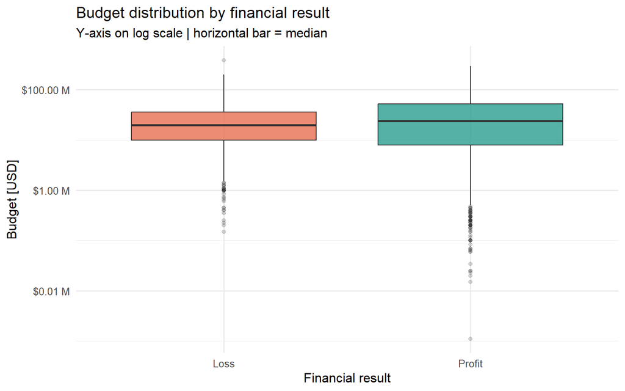

```r
movies %>%
  mutate(result = ifelse(Earnings >= 0, "Profit", "Loss")) %>%
  ggplot(aes(x = result, y = Budget, fill = result)) +
  geom_boxplot(alpha = 0.8, outlier.alpha = 0.2) +
  scale_fill_manual(values = c("Profit" = col_profit, "Loss" = col_loss)) +
  scale_y_log10(labels = label_dollar(scale = 1e-6, suffix = " M")) +
  labs(
    title    = "Budget distribution by financial result",
    subtitle = "Y-axis on log scale | horizontal bar = median",
    x = "Financial result", y = "Budget [USD]"
  ) +
  guides(fill = "none") +
  theme_minimal(base_size = 12)
```

### Normality check and Wilcoxon rank-sum test

```r
cat("=== Loss-making films (Anderson-Darling) ===\n")
```

```
## === Loss-making films (Anderson-Darling) ===
```

```r
ad.test(movies$Budget[movies$Earnings < 0])
```

```
##
##  Anderson-Darling normality test
##
## data:  movies$Budget[movies$Earnings < 0]
## A = 50.015, p-value < 2.2e-16
```

```r
cat("\n=== Profitable films (Anderson-Darling) ===\n")
```

```
##
## === Profitable films (Anderson-Darling) ===
```

```r
ad.test(movies$Budget[movies$Earnings >= 0])
```

```
##
##  Anderson-Darling normality test
##
## data:  movies$Budget[movies$Earnings >= 0]
## A = 204.08, p-value < 2.2e-16
```

**Anderson-Darling result.** Both groups yield p < 0.001, confirming non-normality in both subgroups. We proceed with the non-parametric **Wilcoxon rank-sum test**.

> **H₀:** The budget distributions of profitable and loss-making films do not differ.

> **H₁:** Profitable films have higher budgets than loss-making films (one-sided test).

```r
wt <- wilcox.test(
  movies$Budget[movies$Earnings >= 0],
  movies$Budget[movies$Earnings <  0],
  alternative = "greater"
)
wt
```

```
##
##  Wilcoxon rank sum test with continuity correction
##
## data:  movies$Budget[movies$Earnings >= 0] and movies$Budget[movies$Earnings < 0]
## W = 1557278, p-value = 0.001683
## alternative hypothesis: true location shift is greater than 0
```

```r
n1   <- sum(movies$Earnings >= 0)
n2   <- sum(movies$Earnings <  0)
r_rb <- 1 - (2 * wt$statistic) / (n1 * n2)
cat(sprintf("Rank-biserial correlation r = %.3f\n", r_rb))
```

```
## Rank-biserial correlation r = -0.062
```

```r
cat("Benchmarks: |r| < 0.10 negligible | 0.10-0.30 small | 0.30-0.50 medium | > 0.50 large\n")
```

```
## Benchmarks: |r| < 0.10 negligible | 0.10-0.30 small | 0.30-0.50 medium | > 0.50 large
```

**Wilcoxon rank-sum result.** W = 1557278, p = 0.0017. We **reject H₀**: profitable films have statistically significantly higher budgets than loss-making films. The rank-biserial effect size r = -0.062 is negligible, meaning the difference is real but modest in practical terms — consistent with the substantial distributional overlap seen in the boxplot above.

**Methodological note.** The Wilcoxon rank-sum test formally assesses stochastic dominance (the probability that a randomly selected profitable film has a higher budget than a randomly selected loss-making one). Interpreting this as a difference in medians additionally requires the assumption that both distributions share the same shape, differing only in location. Given the similar IQR widths visible above, this assumption is plausible but is not formally tested.

## Does IMDb Rating Influence Earnings?

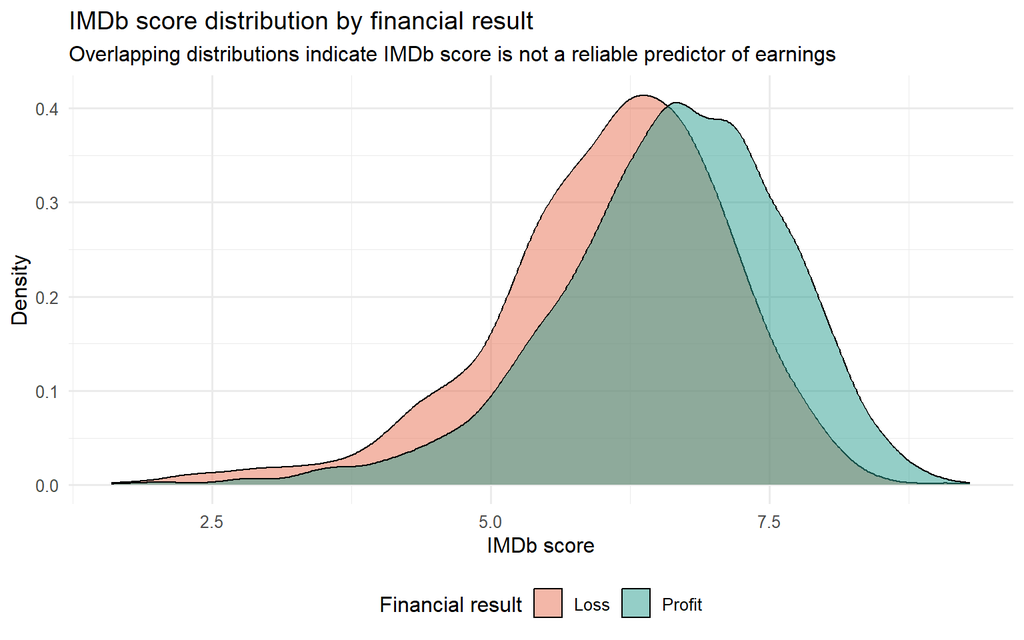

```r
movies %>%
  mutate(result = ifelse(Earnings >= 0, "Profit", "Loss")) %>%
  ggplot(aes(x = `IMDb score`, fill = result)) +
  geom_density(alpha = 0.5) +
  scale_fill_manual(values = c("Profit" = col_profit, "Loss" = col_loss)) +
  labs(
    title    = "IMDb score distribution by financial result",
    subtitle = "Overlapping distributions indicate IMDb score is not a reliable predictor of earnings",
    x = "IMDb score", y = "Density", fill = "Financial result"
  ) +
  theme_minimal(base_size = 12) +
  theme(legend.position = "bottom")
```

## Does a Director’s Track Record Reduce Loss Risk?

Using the director performance quartile groups computed during data preparation, we compare earnings distributions across the four groups:

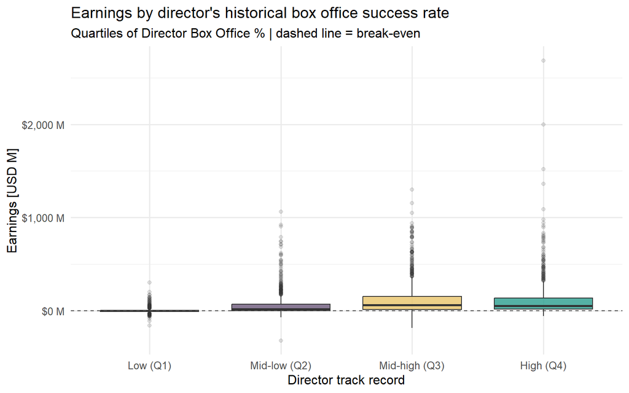

```r
movies %>%
  filter(!is.na(director_group)) %>%
  ggplot(aes(x = director_group, y = Earnings / 1e6, fill = director_group)) +
  geom_boxplot(alpha = 0.8, outlier.alpha = 0.15) +
  geom_hline(yintercept = 0, linetype = "dashed", colour = "grey30") +
  scale_fill_manual(values = c(col_none, col_nom, col_gold, col_profit)) +
  scale_y_continuous(labels = label_dollar(suffix = " M")) +
  labs(
    title    = "Earnings by director's historical box office success rate",
    subtitle = "Quartiles of Director Box Office % | dashed line = break-even",
    x = "Director track record", y = "Earnings [USD M]"
  ) +
  guides(fill = "none") +
  theme_minimal(base_size = 12)
```

```r
movies %>%
  filter(!is.na(director_group)) %>%
  group_by(director_group) %>%
  summarise(
    n        = n(),
    Q1       = round(quantile(Earnings, .25) / 1e6, 1),
    Median   = round(median(Earnings) / 1e6, 1),
    Mean     = round(mean(Earnings) / 1e6, 1),
    Q3       = round(quantile(Earnings, .75) / 1e6, 1),
    `Loss %` = round(mean(Earnings < 0) * 100, 1)
  )
```

| director_group | n | Q1 | Median | Mean | Q3 | Loss % |
| --- | --- | --- | --- | --- | --- | --- |
| Low (Q1) | 1005 | -9.0 | -1.0 | 1.3 | 4.5 | 57.3 |
| Mid-low (Q2) | 1052 | -1.1 | 16.6 | 55.9 | 67.0 | 27.1 |
| Mid-high (Q3) | 916 | 10.7 | 60.0 | 125.2 | 152.2 | 13.3 |
| High (Q4) | 977 | 14.0 | 49.0 | 110.9 | 134.0 | 0.8 |

### Top 10 directors by median earnings

The chart below shows the ten most consistently profitable directors in the dataset, restricted to those with at least five films to ensure the median is based on a sufficiently stable sample:

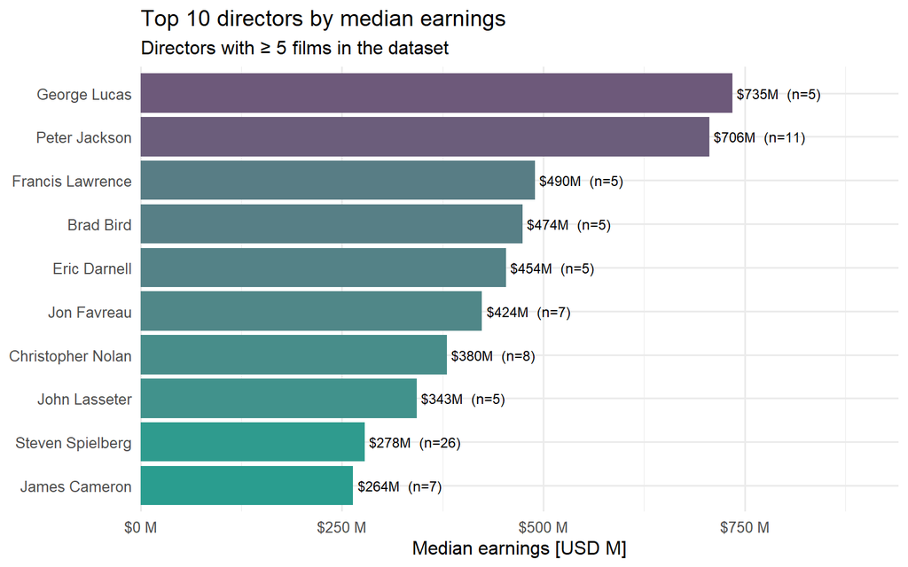

```r
movies %>%
  group_by(Director) %>%
  summarise(n_films = n(), median_earnings = median(Earnings) / 1e6,
            .groups = "drop") %>%
  filter(n_films >= 5) %>%
  slice_max(median_earnings, n = 10) %>%
  ggplot(aes(x = reorder(Director, median_earnings), y = median_earnings,
             fill = median_earnings)) +
  geom_col(show.legend = FALSE) +
  geom_text(aes(label = paste0("$", round(median_earnings), "M  (n=", n_films, ")")),
            hjust = -0.05, size = 3.2) +
  coord_flip(clip = "off") +
  scale_fill_gradient(low = col_profit, high = col_nom) +
  scale_y_continuous(labels = label_dollar(suffix = " M"),
                     expand = expansion(mult = c(0, 0.28))) +
  labs(
    title    = "Top 10 directors by median earnings",
    subtitle = "Directors with ≥ 5 films in the dataset",
    x = NULL, y = "Median earnings [USD M]"
  ) +
  theme_minimal(base_size = 12)
```

The five-film threshold is an accepted rule of thumb for median stability, but is admittedly arbitrary. Rankings for directors close to the cut-off should be treated with appropriate caution.

# What Influences IMDb Ratings?

## IMDb Score Distribution

Before examining potential predictors, we inspect the distribution of the outcome variable itself:

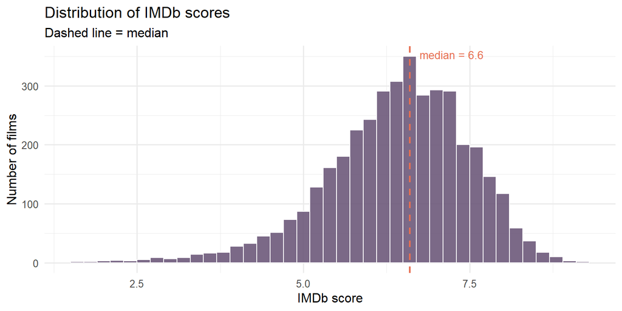

```r
ggplot(movies, aes(x = `IMDb score`)) +
  geom_histogram(binwidth = 0.2, fill = col_nom, colour = "white", alpha = 0.9) +
  geom_vline(xintercept = median(movies$`IMDb score`),
             linetype = "dashed", colour = col_loss, linewidth = 0.8) +
  annotate("text",
           x     = median(movies$`IMDb score`) + 0.15,
           y     = Inf,
           label = paste0("median = ", round(median(movies$`IMDb score`), 2)),
           vjust = 1.5, hjust = 0, size = 3.5, colour = col_loss) +
  labs(title = "Distribution of IMDb scores", subtitle = "Dashed line = median",
       x = "IMDb score", y = "Number of films") +
  theme_minimal(base_size = 12)
```

```r
summary(movies$`IMDb score`)
```

```
##    Min. 1st Qu.  Median    Mean 3rd Qu.    Max.
##   1.600   5.900   6.600   6.468   7.200   9.300
```

## Does a Higher Budget Lead to Better Ratings?

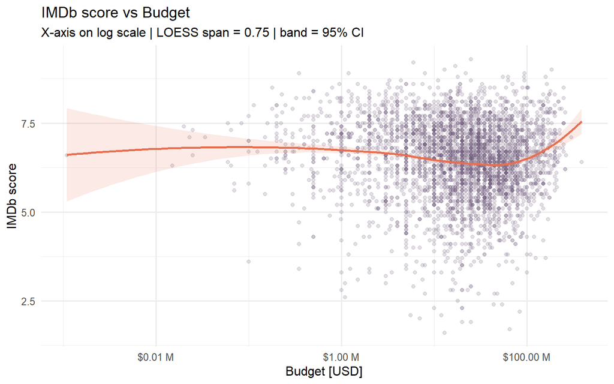

```r
ggplot(movies, aes(x = Budget, y = `IMDb score`)) +
  geom_point(alpha = 0.2, colour = col_nom) +
  geom_smooth(method = "loess", span = 0.75, se = TRUE,
              colour = col_loss, fill = col_loss, alpha = 0.15, linewidth = 1) +
  scale_x_log10(labels = label_dollar(scale = 1e-6, suffix = " M")) +
  labs(title = "IMDb score vs Budget",
       subtitle = "X-axis on log scale | LOESS span = 0.75 | band = 95% CI",
       x = "Budget [USD]", y = "IMDb score") +
  theme_minimal(base_size = 12)
```

The LOESS smoother is nearly flat across virtually the entire budget range, indicating that production spend has little bearing on how audiences rate a film. A slight upward curve is visible at very high budgets (above $100M), but the scatter around the curve is enormous. Both micro-budget productions and $200M blockbusters span the full range of IMDb scores.

### Spearman correlation test

> **H₀:** No monotonic association between Budget and IMDb score.

> **H₁:** A monotonic association exists.

```r
budget_cor <- cor.test(movies$Budget, movies$`IMDb score`, method = "spearman")
budget_cor
```

```
##
##  Spearman's rank correlation rho
##
## data:  movies$Budget and movies$`IMDb score`
## S = 1.1195e+10, p-value = 1.524e-08
## alternative hypothesis: true rho is not equal to 0
## sample estimates:
##         rho
## -0.08988553
```

```r
cat(sprintf("\nEffect size: |rho| = %.3f -> %s\n",
            abs(budget_cor$estimate), effect_label(budget_cor$estimate)))
```

```
##
## Effect size: |rho| = 0.090 -> negligible
```

**Spearman correlation result (Budget ~ IMDb score).** ρ = -0.09, p < 0.001. The association is statistically significant but negligible in practical terms. Budget explains only a negligible share of the variation in IMDb scores — consistent with the near-flat LOESS curve observed above.

## Does Box Office Success Influence Ratings?

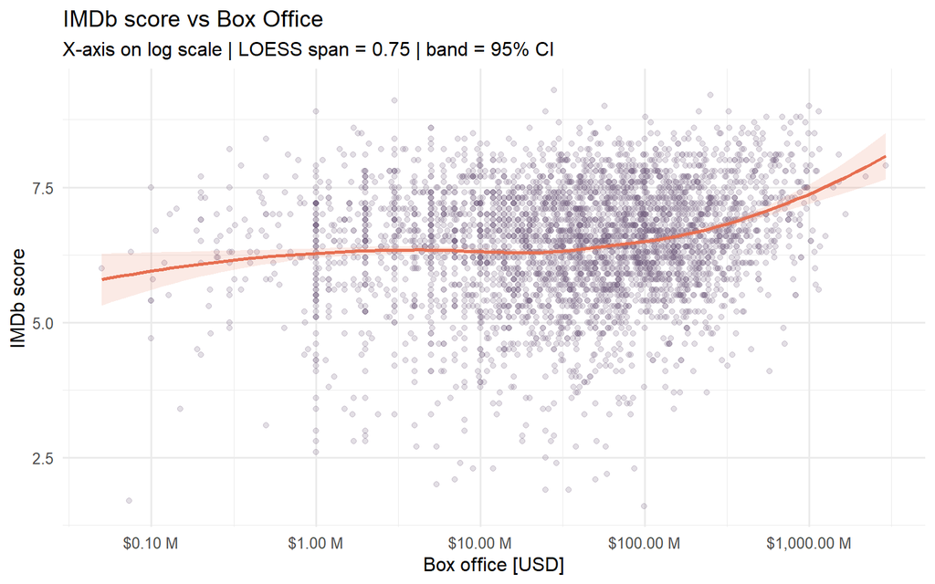

```r
ggplot(movies, aes(x = `Box Office`, y = `IMDb score`)) +
  geom_point(alpha = 0.2, colour = col_nom) +
  geom_smooth(method = "loess", span = 0.75, se = TRUE,
              colour = col_loss, fill = col_loss, alpha = 0.15, linewidth = 1) +
  scale_x_log10(labels = label_dollar(scale = 1e-6, suffix = " M")) +
  labs(title = "IMDb score vs Box Office",
       subtitle = "X-axis on log scale | LOESS span = 0.75 | band = 95% CI",
       x = "Box office [USD]", y = "IMDb score") +
  theme_minimal(base_size = 12)
```

The pattern here is somewhat more pronounced than for budget. The LOESS curve traces a modest positive trend — films that attracted larger audiences tend to receive marginally higher IMDb scores. This could reflect a selection effect (widely seen films accumulate more ratings, including from fans who sought them out precisely because they expected to enjoy them) or simply the fact that commercial and critical success are not independent.

### Spearman correlation test

> **H₀:** No monotonic association between Box Office and IMDb score.

> **H₁:** A monotonic association exists.

```r
bo_cor <- cor.test(movies$`Box Office`, movies$`IMDb score`, method = "spearman")
bo_cor
```

```
##
##  Spearman's rank correlation rho
##
## data:  movies$`Box Office` and movies$`IMDb score`
## S = 8744736239, p-value < 2.2e-16
## alternative hypothesis: true rho is not equal to 0
## sample estimates:
##       rho
## 0.1486528
```

```r
cat(sprintf("\nEffect size: |rho| = %.3f -> %s\n",
            abs(bo_cor$estimate), effect_label(bo_cor$estimate)))
```

```
##
## Effect size: |rho| = 0.149 -> small
```

**Spearman correlation result (Box Office ~ IMDb score).** ρ = 0.149, p < 0.001. The association is statistically significant and slightly stronger than for budget, but still small by Cohen’s benchmarks. Box office revenue and IMDb score co-vary, but the relationship explains only a small fraction of the variance in ratings.

## How Do Nominations Influence Ratings?

```r
cat("Distribution of nomination counts:\n")
```

```
## Distribution of nomination counts:
```

```r
table(movies$`Oscar and Golden Globes nominations`)
```

```
##
##    0    1    2    3    4    5    6    7    8    9   10   11   12   13   14   15
## 2816  455  170  101   60   70   51   38   42   24   30   21   18   14   11    9
##   16   17   18   19   20   22
##    5    2    9    1    1    2
```

Over 70% of films in the dataset received no nominations whatsoever. Films with six or more nominations form a small but highly distinctive group, likely representing the most acclaimed productions in the dataset. To visualise how ratings relate to nomination count, we group films into four bands:

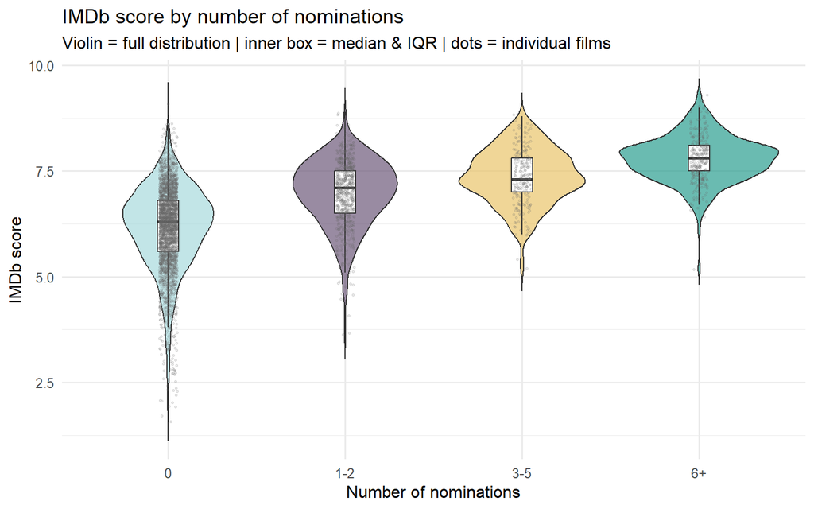

```r
movies %>%
  mutate(
    nom_group = cut(`Oscar and Golden Globes nominations`,
                    breaks = c(-1, 0, 2, 5, Inf),
                    labels = c("0", "1-2", "3-5", "6+"))
  ) %>%
  ggplot(aes(x = nom_group, y = `IMDb score`, fill = nom_group)) +
  geom_violin(alpha = 0.7, trim = FALSE) +
  geom_boxplot(width = 0.12, fill = "white", outlier.shape = NA) +
  geom_jitter(width = 0.05, alpha = 0.15, size = 0.6, colour = "grey40") +
  scale_fill_manual(values = c(col_none, col_nom, col_gold, col_profit)) +
  labs(
    title    = "IMDb score by number of nominations",
    subtitle = "Violin = full distribution | inner box = median & IQR | dots = individual films",
    x = "Number of nominations", y = "IMDb score"
  ) +
  guides(fill = "none") +
  theme_minimal(base_size = 12)
```

The violin shapes tell a clear story: as nomination count increases, the entire distribution shifts upward and narrows considerably. Films with no nominations show a broad distribution centred around 6–6.5 with a long left tail. The 6+ group, by contrast, is tightly concentrated between 7 and 8.5 with very few films below 7. Greater industry recognition is strongly associated with both higher and more consistent audience ratings.

## Does Winning an Award Have a Stronger Effect Than a Nomination Alone?

```r
cat("Distribution of award counts:\n")
```

```
## Distribution of award counts:
```

```r
table(movies$`Oscar and Golden Globes awards`)
```

```
##
##    0    1    2    3    4    5    6    7    8    9   10   11   12   13
## 3483  208   93   39   41   29   17   14    8    7    2    3    2    4
```

[figure not shown]

```r
movies %>%
  assign_award_group() %>%
  ggplot(aes(x = award_group, y = `IMDb score`, fill = award_group)) +
  geom_violin(alpha = 0.7, trim = FALSE) +
  geom_boxplot(width = 0.12, fill = "white", outlier.shape = NA) +
  geom_jitter(width = 0.05, alpha = 0.15, size = 0.6, colour = "grey40") +
  scale_fill_manual(values = c(
    "No nominations"      = col_loss,
    "Nominated, no award" = col_none,
    "At least 1 award"    = col_gold
  )) +
  labs(
    title    = "IMDb score by award and nomination status",
    subtitle = "Violin + boxplot + jitter | orange = no nominations, teal = nominated, gold = awarded",
    x = NULL, y = "IMDb score"
  ) +
  guides(fill = "none") +
  theme_minimal(base_size = 12)
```

The three distributions are cleanly ordered and clearly separated. Films with no nominations have the widest spread, with a pronounced left tail representing the many productions that received poor audience scores. Nominated-but-not-awarded films occupy a well-defined intermediate position, with the distribution shifted upward and the lower tail substantially shortened. Award-winning films form the tightest cluster, centred around 7.5–8 with very few films below 7. **Winning an award is associated with a stronger and more consistent uplift in IMDb scores than receiving a nomination alone.**

# Are Industry-Recognised Films Longer?

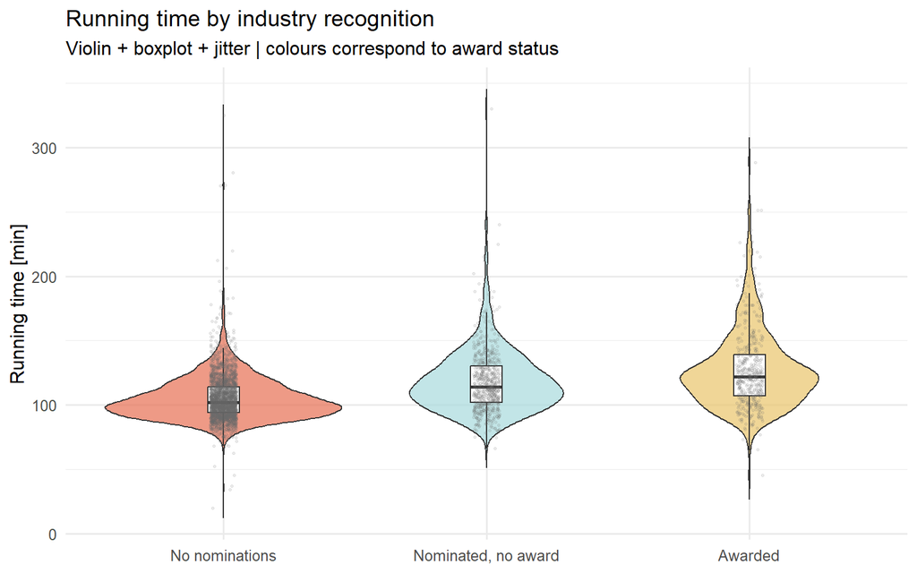

```r
movies %>%
  assign_award_group(labels = c("No nominations", "Nominated, no award", "Awarded")) %>%
  ggplot(aes(x = award_group, y = `Running time`, fill = award_group)) +
  geom_violin(alpha = 0.7, trim = FALSE) +
  geom_boxplot(width = 0.12, fill = "white", outlier.shape = NA) +
  geom_jitter(width = 0.05, alpha = 0.12, size = 0.6, colour = "grey40") +
  scale_fill_manual(values = c(
    "No nominations"      = col_loss,
    "Nominated, no award" = col_none,
    "Awarded"             = col_gold
  )) +
  labs(title = "Running time by industry recognition",
       subtitle = "Violin + boxplot + jitter | colours correspond to award status",
       x = NULL, y = "Running time [min]") +
  guides(fill = "none") +
  theme_minimal(base_size = 12)
```

A clear monotonic pattern emerges across award status groups. Films with no nominations cluster tightly in the 85–120 minute range — the standard commercial runtime. Nominated films spread more broadly, with a higher median and a longer right tail. Awarded films are the longest on average, with substantial right-skewness that reflects the inclusion of epic productions exceeding 150 minutes. This pattern is consistent with the idea that narratively ambitious, longer-form films receive more critical attention — though it is equally plausible that prestigious films simply have more resources and creative latitude to exceed standard runtime conventions.

# Are Newer Films Rated Lower?

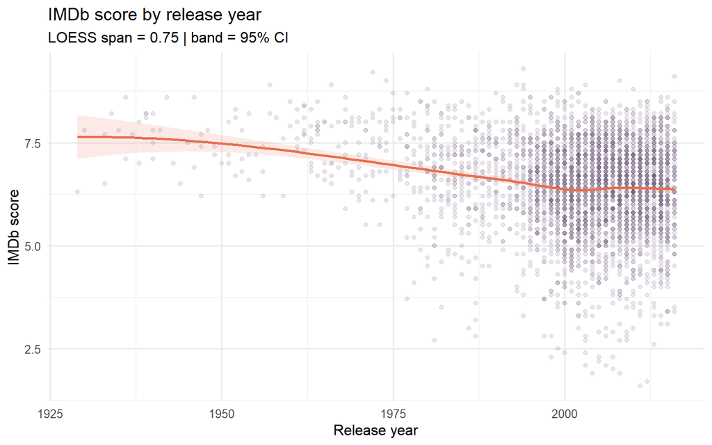

```r
ggplot(movies, aes(x = `Release year`, y = `IMDb score`)) +
  geom_point(alpha = 0.15, colour = col_nom) +
  geom_smooth(method = "loess", span = 0.75, se = TRUE,
              colour = col_loss, fill = col_loss, alpha = 0.15, linewidth = 1) +
  labs(title = "IMDb score by release year",
       subtitle = "LOESS span = 0.75 | band = 95% CI",
       x = "Release year", y = "IMDb score") +
  theme_minimal(base_size = 12)
```

[figure not shown]

```r
movies %>%
  mutate(decade = (`Release year` %/% 10) * 10) %>%
  group_by(decade) %>%
  summarise(median_imdb = median(`IMDb score`), n = n(), .groups = "drop") %>%
  filter(n >= 20) %>%
  ggplot(aes(x = factor(decade), y = median_imdb, fill = median_imdb)) +
  geom_col(show.legend = FALSE, width = 0.7) +
  geom_text(aes(label = paste0(round(median_imdb, 2), "\n(n=", n, ")")),
            vjust = -0.3, size = 3.2, lineheight = 1.1) +
  scale_fill_gradient(low = col_loss, high = col_profit) +
  scale_y_continuous(expand = expansion(mult = c(0, 0.15))) +
  labs(title = "Median IMDb score by decade",
       subtitle = "Decades with >= 20 films | n shown per bar",
       x = "Decade", y = "Median IMDb score") +
  theme_minimal(base_size = 12)
```

The decline from the 1960s–70s to the 2000s–10s is visible but requires careful interpretation. The n values shown in the bars are essential context: pre-1970 decades contain very few films, meaning those estimates rest on small and highly selective samples. Films old enough and notable enough to appear in this dataset and to have attracted meaningful numbers of IMDb ratings are, by definition, a curated elite of classic cinema. More recent decades are represented by thousands of productions of varying quality. **The observed rating decline most plausibly reflects survivorship bias and a change in the composition of the rating audience, rather than a genuine decline in film quality over time.**

### Spearman correlation test

We apply Spearman correlation because release year is ordinal in nature, the IMDb score is bounded to 1–10, the relationship may be non-linear, and the method is robust to outliers.

> **H₀:** No monotonic association between release year and IMDb score.

> **H₁:** A monotonic association exists.

```r
year_cor <- cor.test(movies$`Release year`, movies$`IMDb score`,
                     method = "spearman")
year_cor
```

```
##
##  Spearman's rank correlation rho
##
## data:  movies$`Release year` and movies$`IMDb score`
## S = 1.1602e+10, p-value = 3.054e-16
## alternative hypothesis: true rho is not equal to 0
## sample estimates:
##        rho
## -0.1295058
```

```r
cat(sprintf("\nEffect size: |rho| = %.3f -> %s\n",
            abs(year_cor$estimate), effect_label(year_cor$estimate)))
```

```
##
## Effect size: |rho| = 0.130 -> small
```

**Spearman correlation result (Release year ~ IMDb score).** ρ = -0.13, p < 0.001. We **reject H₀**: there is a statistically significant negative association between release year and IMDb score. The effect size is small by Cohen’s benchmarks — release year accounts for a minimal fraction of the variance in ratings. The statistical signal is real, but its cause is almost certainly a compositional artefact (survivorship bias and audience demographics) rather than a genuine temporal trend in film quality.

# Summary

This exploratory data analysis covered 3950 feature films and investigated three main areas: the determinants of financial outcome, the factors associated with IMDb ratings, and the characteristics of industry-recognised productions.

**IMDb scores** are weakly but significantly associated with both budget (ρ = -0.09, negligible effect) and box office revenue (ρ = 0.149, small effect). Far stronger associations emerge with industry recognition: films receiving multiple nominations and, especially, award wins achieve markedly higher and more tightly clustered ratings. The rating advantage of award-winning films over non-nominated films is clearly visible even without formal testing. Newer films carry marginally lower ratings on average (ρ = -0.13, small effect), but this is most plausibly explained by survivorship bias and audience demographic shifts rather than any decline in production quality.

**Industry-recognised films** are systematically longer, better-rated, and more financially variable than films without nominations. The co-occurrence of high audience ratings and industry recognition is consistent across multiple analyses, though — as is appropriate for exploratory work — the direction of any causal relationship between these outcomes cannot be determined from the data alone.

Taken together, the findings reinforce a recurring theme in the economics of cultural industries: film success is the product of many interacting factors, and no single variable — budget, genre, director track record, or release year — is a reliable standalone predictor of either financial performance or audience reception.